# Staying indoors is the new normalcy

# Mobility patterns by state

```python
# group the data by state name and date
groupedStates = states.groupby(['sub_region_1', 'date']).median().drop(['metro_area', 'census_fips_code'], axis=1)
```

```python
groupedStates.rolling(7).mean().reset_index().merge(region, left_on='sub_region_1', right_on='State').to_csv("grouped-by-states-daily-mobility.csv")
```

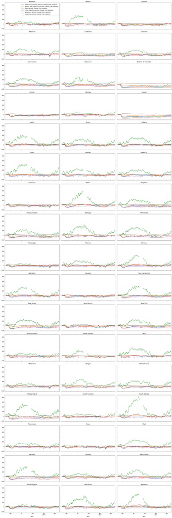

```python
fig, axes = plt.subplots(figsize=(20, 60), nrows=17, ncols=3, sharex=True, sharey=True)

for i in range(len(state_ls)):
    s = state_ls[i]
    selAx= axes[int(math.floor(i/3)), i%3]
    if (i == 0):
        groupedStates.loc[s].rolling(7).mean().plot(ax=selAx, legend=True)
    else:
        groupedStates.loc[s].rolling(7).mean().plot(ax=selAx, legend=False)
    selAx.set_title(s)
fig.tight_layout(pad=1.2)
plt.show()
```

- While mobility patterns of grocery and pharmacy and retail and recreation have almost climbed back to the baseline in some states, such as Alabama, Arizona, Connecticut, Delaware, Georgia, Florida and Maryland, that of workplaces and transit stations are still below zero in most states.
- In D.C., Hawaii, Massachusetts, New York and New Jersey, percent changes in workplaces and transit stations are even below -25%.
- Most states saw an increase in park mobility after the pandemic struck. But dramatic changes in park mobility data, ex. a significant dip during wintertime, might be attributed to weather conditions, as pointed out by Google mobility reports.

## Average mobility patterns in each region

I am comparing the average mobility in the past month and that in the beginning of the pandemic.

Average mobility in the past month: average between April 7, 2021 and May 7, 2021, last collected day when analysis was done.

Average mobility in a year before: average between April 7, 2020 and May 7, 2020.

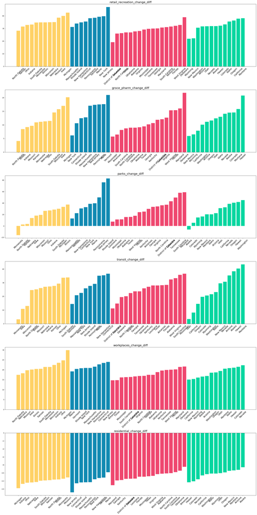

```python
# west: green
# northeast: blue
# midwest: yellow
# south: pink
colors = {'West':'#06d6a0', 'South': '#ef476f', 'Northeast':'#118ab2', 'Midwest': '#ffd166'}

before = states[(states.date >= pd.to_datetime("2020-04-07")) & (states.date <= pd.to_datetime("2020-05-07"))]
now = states[(states.date >= pd.to_datetime("2021-04-07")) & (states.date <= pd.to_datetime("2021-05-07"))]

state_col = [[], [], [], [], [], []]
change_col = [[], [], [], [], [], []]

for i in range(len(state_ls)):
    s = state_ls[i]
    selnow = now[now.sub_region_1 == s].groupby(["date"]).median()
    selbefore = before[before.sub_region_1 == s].groupby(["date"]).median()
    for j in range(len(mobility_ls)):
        m = mobility_ls[j]
        change = selnow[m].mean() - selbefore[m].mean()
        state_col[j].append(s)
        change_col[j].append(change)

recGap = pd.DataFrame()
recGap["state"] = state_col[0]
recGap["retail_recreation_change_diff"] = change_col[0]
recGap["groce_pharm_change_diff"] = change_col[1]
recGap["parks_change_diff"] = change_col[2]
recGap["transit_change_diff"] = change_col[3]
recGap["workplaces_change_diff"] = change_col[4]
recGap["residential_change_diff"] = change_col[5]

recGap = recGap.merge(region, left_on='state', right_on='State')

fig, ax = plt.subplots(figsize=(25, 50), nrows=6)
l = ["retail_recreation_change_diff","groce_pharm_change_diff","parks_change_diff","transit_change_diff","workplaces_change_diff","residential_change_diff"]

for i in range(len(l)):
    mobility = l[i]
    recGap.sort_values(['Region', mobility], inplace=True)
    recGap.reset_index(inplace=True, drop=True)
    d = recGap[['state', 'Region', mobility]]
    ax[i].bar(d.state, d[mobility], color=d.Region.map(colors))
    ax[i].set_title(mobility, fontsize=20)
    ax[i].tick_params(axis='x', labelrotation = 45, labelsize = 16)
fig.tight_layout(pad=1.2)
plt.show()
```